# Object Use Analysis in Gorongosa Baboons

Jd’OC

2023-01-13

## 1. Data Preprocessing

Open the `code` snippet below and to the right to see all data transformations executed to clean the dataset.

```r
################################
####### OCTOBER DATASETS #######
################################

library(plyr); library(dplyr)

# FIRST JOINT, FOCAL DATA

Oct <- read.csv("./rawData/Oct30_2021_Ipad Susana/behaviorsTable.csv")

sessionsTableOct <- read.csv("./rawData/Oct30_2021_Ipad Susana/sessionsTable.csv")

sessionsTableOct <- sessionsTableOct[,c("session_start_timeStamp", "group_ID")]

FocalOctJoin <- join(Oct, sessionsTableOct, by = "session_start_timeStamp")

FocalOctJoin$USE <- "Research"


# Second joint, SCAN DATA

OctScan <- read.csv("./rawData/Oct30_2021_Ipad Susana/scansTable.csv") # 110 obs

HabitatOct <- read.csv("./rawData/Oct30_2021_Ipad Susana/scanVarsTable.csv") # 99 obs

HabitatOct <- HabitatOct[,c("focal_start_timeStamp", "TERRAIN.")]

HabitatOct <- HabitatOct[HabitatOct$TERRAIN. != "", ] # remove rows without terrain
HabitatOct <- unique(HabitatOct) # AVOID DUPLICATES

ScanOctJoin <- join(OctScan, HabitatOct, by = "focal_start_timeStamp")


### SCAN + HabitatOct + GROUP

scan_final_oct <- join(ScanOctJoin, sessionsTableOct, by = "session_start_timeStamp")

write.csv(scan_final_oct, "scan_final_oct.xlsx")

################################
####### JULY DATASETS #########
################################

# FIRST JOINT, FOCAL DATA

Jul <- read.csv("./rawData/Julho17_2022_Ipad Jacinto/behaviorsTable.csv")

Jul[,c("FOOD_ITEM.", "PART_EATEN.")] <- Jul[,c("FOOD_ITEM..1", "PART_EATEN..1")]
Jul <- subset(Jul, select = -c(`FOOD_ITEM..1`, `PART_EATEN..1`))

sessionsTableJul <- read.csv("./rawData/Julho17_2022_Ipad Jacinto/sessionsTable.csv")
sessionsTableJul <- sessionsTableJul[,c("session_start_timeStamp", "group_ID")]

FocalJul <- join(Jul, sessionsTableJul, by = "session_start_timeStamp")

focalVarsJul <- read.csv("./rawData/Julho17_2022_Ipad Jacinto/focalVarsTable.csv")
focalVarsJul <- focalVarsJul[,c("session_start_timeStamp", "USE")]
focalVarsJul <- focalVarsJul[which(focalVarsJul$USE == "Research"),]
focalVarsJul <- unique(focalVarsJul)

FocalJulJoin <- left_join(FocalJul, focalVarsJul, by = "session_start_timeStamp")

write.csv(FocalJulJoin,"./tables/FocalJulJoin.csv")

# Second scans + HabitatOct, SCAN DATA

JulScan <- read.csv("./rawData/Julho17_2022_Ipad Jacinto/scansTable.csv") # 1445 obs

HabitatJul <- read.csv("./rawData/Julho17_2022_Ipad Jacinto/scanVarsTable.csv") # 1437 obs

HabitatJul <- HabitatJul[,c("focal_start_timeStamp", "TERRAIN.")]
HabitatJul <- HabitatJul[HabitatJul$TERRAIN. != "", ] # remove rows without terrain
HabitatJul <- unique(HabitatJul) # AVOID DUPLICATES

ScanJulJoin <- join(JulScan, HabitatJul, by = "focal_start_timeStamp")

write.csv(ScanJulJoin, "./tables/ScanJulJoin.csv")

### SCAN + HABITAT + GROUP

scan_final_jul <- join(ScanJulJoin, sessionsTableJul, by = "session_start_timeStamp")

write.csv(scan_final_jul, "scan_final_jul.xlsx")

### FOCAL OCT + FOCAL JULY

focalFinal <- rbind(FocalJulJoin, FocalOctJoin) # 2290 obs
focalFinal$session_start_timeStamp <- as.POSIXct(focalFinal$session_start_timeStamp, format = "%Y-%m-%d,%H:%M:%S")

### SCAN OCT + FOCAL JULY

scanFinal <- rbind(scan_final_jul, scan_final_oct) # 1555 obs
scanFinal$session_start_timeStamp <- as.POSIXct(scanFinal$session_start_timeStamp, format = "%Y-%m-%d,%H:%M:%S")


### Get Habitat values into FOCAL DATASET

scanHabitats <- scanFinal[, c("session_start_timeStamp", "TERRAIN.")]
scanHabitats <- unique(scanHabitats[!is.na(scanHabitats$TERRAIN.),])
scanHabitats <- scanHabitats[!duplicated(scanHabitats$session_start_timeStamp), ]

# Fill habitat NAs, anti_join() return all rows from x without a match in y.
missing_values <- anti_join(focalFinal, scanHabitats, by = "session_start_timeStamp")
missing_values$TERRAIN. <- NA
missing_values <- missing_values[,c("session_start_timeStamp", "TERRAIN.")]

for (i in 1:nrow(missing_values)) {
  time_differences <- difftime(missing_values$session_start_timeStamp[i], scanHabitats$session_start_timeStamp, units = "secs")
  closest_index <- which.min(abs(time_differences))
  missing_values$TERRAIN.[i] <- scanHabitats$TERRAIN.[closest_index]
}

scan_habitats <- rbind(scanHabitats, unique(missing_values))
remove_set <- anti_join(scan_habitats, focalFinal,  by = "session_start_timeStamp")
habitatFinal <- anti_join(scan_habitats, remove_set,  by = "session_start_timeStamp")

final_set <- join(focalFinal, unique(habitatFinal), by = "session_start_timeStamp")
final_set <- final_set[, colSums(is.na(final_set)) != nrow(final_set)] # remove all empty columns

#########################################
######## EDIT TERRAIN VARIABLE ##########
#########################################

final_set$TERRAIN. <- ifelse(final_set$TERRAIN. == "Closed woodland (50-75%);Road", "Closed woodland (50-75%)", final_set$TERRAIN.)
final_set$TERRAIN. <- ifelse(final_set$TERRAIN. == "Floodplain Grass", "Floodplain", final_set$TERRAIN.)
final_set$TERRAIN. <- ifelse(final_set$TERRAIN. == "Floodplain;Floodplain Grass", "Floodplain", final_set$TERRAIN.)
final_set$TERRAIN. <- ifelse(final_set$TERRAIN. == "Moderate woodland (10-50%);Road", "Moderate woodland (10-50%)", final_set$TERRAIN.)
final_set$TERRAIN. <- ifelse(final_set$TERRAIN. == "Open woodland (1-10%);Moderate woodland (10-50%)", "Moderate woodland (10-50%)", final_set$TERRAIN.)
final_set$TERRAIN. <- ifelse(final_set$TERRAIN. == "Sparse woodland (<1%);Floodplain", "Sparse woodland (<1%)", final_set$TERRAIN.)
final_set$TERRAIN. <- ifelse(final_set$TERRAIN. == "Sparse woodland (<1%);Floodplain Grass", "Sparse woodland (<1%)", final_set$TERRAIN.)
final_set$TERRAIN. <- ifelse(final_set$TERRAIN. == "Sparse woodland (<1%);Open woodland (1-10%)", "Sparse woodland (<1%)", final_set$TERRAIN.)

#########################################
########### ADD AGE AND SEX #############
#########################################

demographics <- read.csv("demographics.csv")
final_set <- left_join(final_set, demographics, by = "actor")

#########################################
########### FINAL CLEANING ##############
#########################################

final_set <- final_set[!is.na(final_set$USE),] # remove non-research instances
final_set <- final_set[final_set$group_ID != "Bones of Predation",] # remove non-research instances
final_set <- final_set[final_set$Sex != "",] # remove Empty "" obsv in Sex

final_set$ObjectUse <- ifelse(final_set$Activity != "Object Use", "Other", final_set$Activity)

idx <- which(final_set$Obj_Type == "")

final_set$Anthropogenic <- ifelse(final_set$Obj_Type != "Man-made", "Non-anthropogenic", final_set$Obj_Type)
final_set$Anthropogenic[idx] <- ""

idx2 <- final_set$Anthropogenic == "Man-made"
final_set$Anthropogenic[idx2] <- "Anthropogenic"

final_set <- final_set[-2211, ] # Remove line with Tool Use obsv test

library(rio)
library(dplyr)
library(lme4)

ObjectUse <- final_set

ObjectUse$focal_start_timeStamp <- as.POSIXct(ObjectUse$focal_start_timeStamp, format = "%Y-%m-%d,%H:%M:%S")

days <- format(as.Date(ObjectUse$focal_start_timeStamp, format="%Y-%m-%d,%H:%M:%S"),"%Y-%m-%d")


# reorder AGE levels for aesthetics in graphics
ObjectUse$Age <- factor(
  ObjectUse$Age,
  levels = c(
    'Infant', 'Juvenile', 'Subadult', 'Adult'
  )
)
ObjectUse$Sex <- factor(ObjectUse$Sex)

ObjectUse$ObjectUse <- factor(ObjectUse$ObjectUse,
                              levels = c("Other", "Object Use"))

# reorder HABITAT levels for aesthetics + change variable name
ObjectUse$Habitat <- factor(
  ObjectUse$TERRAIN.,
  levels = c(
    "Floodplain",
    "Sparse woodland (<1%)",
    "Open woodland (1-10%)",
    "Moderate woodland (10-50%)",
    "Closed woodland (50-75%)"
  )
)

# Create new variable Behaviour / based on "Activity" + "Object Function"

library(forcats)

ObjectUse$Behaviour <- fct_collapse(ObjectUse$Activity, "Vocalization" = c("Bark", "Wahoo")) # join variables (low n)

ObjectUse$Behaviour <- fct_collapse(ObjectUse$Behaviour, "Moving" = c("Locomotion", "Move", "Travel")) # join variables (similar)

ObjectUse$Behaviour <- fct_collapse(ObjectUse$Behaviour, "Forage" = c("Forage", "Hunt")) # join variables (low n)


ObjectUse$Behaviour <- as.character(ObjectUse$Behaviour) # convert to string for next operation
ObjectUse$Behaviour[ObjectUse$Activity == "Object Use"] <- paste("Object Use:", ObjectUse$ObjFunction[ObjectUse$Activity == "Object Use"]) # get object function to break object use into multiple categories

ObjectUse$ObjFunction <- as.factor(ObjectUse$ObjFunction)

n_focals <- length(unique(ObjectUse$focal_start_timeStamp))
min_focal <- 10 # each focal took 10 minutes

ObjectUse$Play_Type <- factor(ObjectUse$Play_Type)

functionset <- ObjectUse[ObjectUse$ObjFunction != "",]
playset <- ObjectUse[ObjectUse$Play_Type != "",]

objPlay <- functionset[functionset$ObjFunction == "Play", ]
objPlayset <- rbind(playset, objPlay)

functionset$ObjectFunction <- ifelse(functionset$ObjFunction != "Food processing", "Object manipulation", as.character(functionset$ObjFunction))

functionset$ObjectFunction <- factor(functionset$ObjectFunction, levels = c("Object manipulation", "Food processing"))

objPlayset$Play_Obj <- factor(objPlayset$Activity)
levels(objPlayset$Play_Obj) <- c("Play with Object", "Play without Object")
objPlayset$Play_Obj <- factor(objPlayset$Play_Obj, levels = c("Play without Object", "Play with Object"))
```

## 2. Data Structure

```r
str(ObjectUse)
```

```
## 'data.frame':    2262 obs. of  40 variables:
##  $ device_ID               : chr  "9C6AA987-85B3-4DEB-90DE-2F7611880AA4" "9C6AA987-85B3-4DEB-90DE-2F7611880AA4" "9C6AA987-85B3-4DEB-90DE-2F7611880AA4" "9C6AA987-85B3-4DEB-90DE-2F7611880AA4" ...
##  $ session_start_timeStamp : POSIXct, format: "2021-11-02 07:16:28" "2021-11-02 07:16:28" ...
##  $ focal_start_timeStamp   : POSIXct, format: "2021-11-02 08:08:56" "2021-11-02 08:08:56" ...
##  $ behavior_timeStamp      : chr  "2021-11-02,08:09:19" "2021-11-02,08:10:09" "2021-11-02,08:10:37" "2021-11-02,08:10:50" ...
##  $ actor                   : chr  "AFV1" "AFV1" "AFV1" "AFV1" ...
##  $ subject                 : chr  "AFV1" "AFV1" "AFV1" "AFV1" ...
##  $ FOOD_ITEM.              : chr  "" "Grass" "" "Grass" ...
##  $ PART_EATEN.             : chr  "" "Root" "" "Root" ...
##  $ Activity                : chr  "Object Use" "Forage" "Locomotion" "Forage" ...
##  $ Locomotion_Type         : chr  "" "" "Quadrupedal" "" ...
##  $ Bipedal_Type            : chr  "" "" "" "" ...
##  $ Location                : chr  "Ground" "Ground" "Ground" "Ground" ...
##  $ Vigilant                : chr  "No" "Yes" "No" "No" ...
##  $ Shade                   : chr  "Sun" "Sun" "Sun" "Sun" ...
```

[output cut: 26 more lines]

After processing the data we obtained a cleaned data set, **with 2262 observations (rows)**, and a **total of 40 variables (columns)**. The variables are the following: device_ID, session_start_timeStamp, focal_start_timeStamp, behavior_timeStamp, actor, subject, FOOD_ITEM., PART_EATEN., Activity, Locomotion_Type, Bipedal_Type, Location, Vigilant, Shade, Vig_At, Height, Carrying_Type, Object, ObjFunction, Obj_Type, Obj_N, Obj_Mob, Obj_Lat, Observers, Play_Type, Speed, Direction., latitude, longitude, gps_horizontal_precision, altitude, group_ID, USE, TERRAIN., Sex, Age, ObjectUse, Anthropogenic, Habitat, Behaviour

There was a total of 197 focals, each with a total time of 10 minutes, meaning that the total time of observation was 1970 min. A total of approximately 32 hours and 50 minutes, sampled over a period of 57 days.

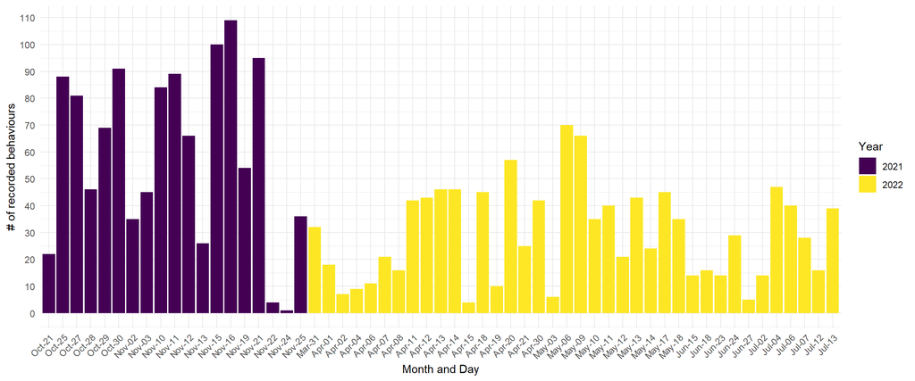

```r
library(ggplot2)

# Convert behavior_timeStamp to Date format
ObjectUse$behaviorDays <- as.Date(ObjectUse$behavior_timeStamp)

# Order dates
ObjectUse$behaviorDays <- ObjectUse$behaviorDays[order(ObjectUse$behaviorDays, decreasing = FALSE)]

# Create a new column for the month and day
ObjectUse$month_and_day <- as.factor(format(ObjectUse$behaviorDays, "%b-%d"))

# Reorder month_and_day
ObjectUse$month_and_day <- factor(ObjectUse$month_and_day, levels = unique(ObjectUse$month_and_day))

# Plot the frequency of behavior_timeStamp per day and year using ggplot2
ggplot(ObjectUse, aes(x = month_and_day, fill = as.factor(format(behaviorDays, "%Y")))) +
  geom_bar() +
  labs(x = "Month and Day", y = "# of recorded behaviours") +
  theme_minimal() +
  scale_fill_viridis_d(option = "D", name = "Year") +
  theme(axis.text.x = element_text(angle = 45, hjust = 1)) +
  scale_y_continuous(breaks = seq(0, 120, by = 10))
```

#### List of days with Focals:

```r
indDays <- order(unique(days), decreasing = FALSE)

unique(days)[indDays]
```

```
##  [1] "2021-10-21" "2021-10-25" "2021-10-27" "2021-10-28" "2021-10-29"
##  [6] "2021-10-30" "2021-11-02" "2021-11-03" "2021-11-10" "2021-11-11"
## [11] "2021-11-12" "2021-11-13" "2021-11-15" "2021-11-16" "2021-11-19"
## [16] "2021-11-21" "2021-11-22" "2021-11-24" "2021-11-25" "2022-03-31"
## [21] "2022-04-01" "2022-04-02" "2022-04-04" "2022-04-06" "2022-04-07"
## [26] "2022-04-08" "2022-04-11" "2022-04-12" "2022-04-13" "2022-04-14"
## [31] "2022-04-15" "2022-04-18" "2022-04-19" "2022-04-20" "2022-04-21"
## [36] "2022-04-30" "2022-05-03" "2022-05-06" "2022-05-09" "2022-05-10"
## [41] "2022-05-11" "2022-05-12" "2022-05-13" "2022-05-14" "2022-05-17"
## [46] "2022-05-18" "2022-06-15" "2022-06-18" "2022-06-23" "2022-06-24"
## [51] "2022-06-27" "2022-07-02" "2022-07-04" "2022-07-06" "2022-07-07"
## [56] "2022-07-12" "2022-07-13"
```

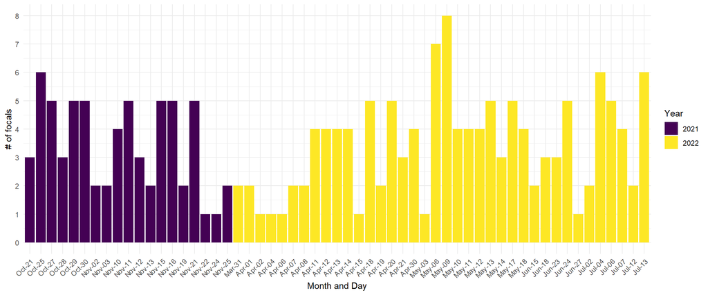

```r
uniqueFocals <- unique(ObjectUse[, c("focal_start_timeStamp")])

# Order dates
uniqueFocals <- as.data.frame(uniqueFocals[order(uniqueFocals, decreasing = FALSE)])

# Convert behavior_timeStamp to Date format
uniqueFocals$Days <- as.Date(uniqueFocals[,1])

# Create a new column for the month and day
uniqueFocals$fmonth_and_day <- as.factor(format(uniqueFocals$Days, "%b-%d"))

# Reorder month_and_day
uniqueFocals$fmonth_and_day <- factor(uniqueFocals$fmonth_and_day, levels = unique(uniqueFocals$fmonth_and_day))

# Plot the frequency of behavior_timeStamp per day and year using ggplot2
ggplot(uniqueFocals, aes(x = fmonth_and_day, fill = as.factor(format(Days, "%Y")))) +
  geom_bar() +
  labs(x = "Month and Day", y = "# of focals") +
  theme_minimal() +
  scale_fill_viridis_d(option = "D", name = "Year") +
  theme(axis.text.x = element_text(angle = 45, hjust = 1)) +
  scale_y_continuous(breaks = seq(0, 8, by = 1))
```

Mean n of focals per day = 3.456 *

*this only considers days where at least 1 focal occurred.

#### Individuals observed:

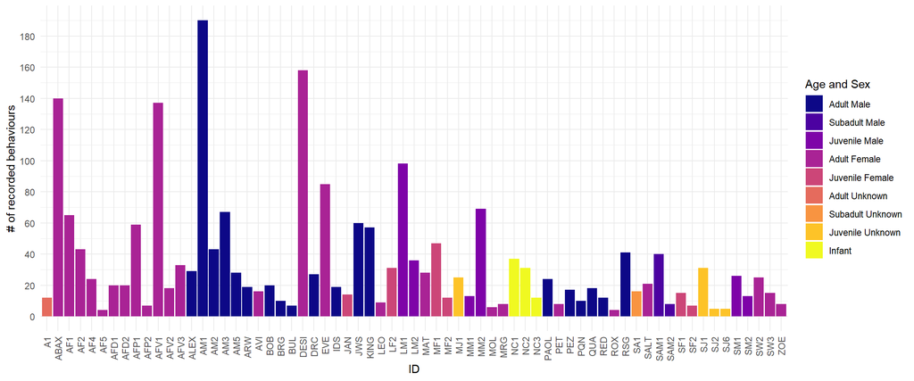

```r
# Create a new variable "sex-and-age"
ObjectUse$age_and_sex <- as.factor(paste(ObjectUse$Age, ObjectUse$Sex))

levels(ObjectUse$age_and_sex) <- c("Adult Female", "Adult Male", "Adult Unknown", "Infant", "Juvenile Female", "Juvenile Male", "Juvenile Unknown", "Subadult Male", "Subadult Unknown")

ObjectUse$age_and_sex <- factor(ObjectUse$age_and_sex, levels = c("Adult Male", "Subadult Male", "Juvenile Male", "Adult Female", "Juvenile Female", "Adult Unknown", "Subadult Unknown", "Juvenile Unknown", "Infant"))

# Plot the frequency of behavior_timeStamp per day and year using ggplot2
ggplot(ObjectUse, aes(x = actor, fill = age_and_sex)) +
  geom_bar() +
  labs(x = "ID", y = "# of recorded behaviours") +
  theme_minimal() +
  scale_fill_viridis_d(option = "C", name = "Age and Sex") +
  theme(axis.text.x = element_text(angle = 90, hjust = 1, vjust = 0.5)) +
  scale_y_continuous(breaks = seq(0, 200, by = 20))
```

## 3. Data vizualization

### Behaviour per Habitat (%) barplot

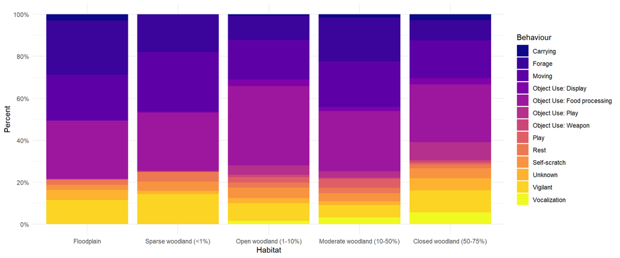

```r
ggplot(ObjectUse, aes(x = Habitat, fill = Behaviour)) +
  geom_bar(position = "fill") + # Dados em Proporção (corrigidos pelo total de observações)
  scale_y_continuous(breaks = seq(0, 1, .2), label = scales::percent) +
  scale_fill_viridis_d(option = "C") +
  labs(y = "Percent") + theme_minimal()
```

### Behaviour per Habitat (count) barplot

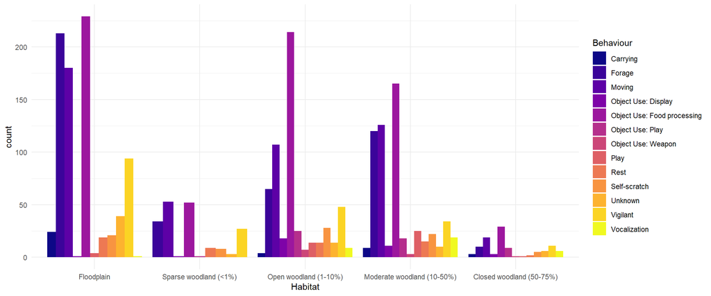

```r
ggplot(ObjectUse, aes(x = Habitat, fill = Behaviour)) +
  geom_bar(position = "dodge") +
  scale_fill_viridis_d(option = "C") +
  theme_minimal()
```

### Behaviour per Age class (%) barplot

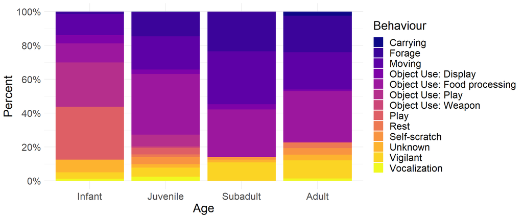

```r
ggplot(ObjectUse, aes(x = Age, fill = Behaviour)) +
  geom_bar(position = "fill") +
  scale_y_continuous(breaks = seq(0, 1, .2), label = scales::percent) +
  scale_fill_viridis_d(option = "C") +
  labs(fill = "Behaviour", y = "Percent") + theme_minimal() +
  theme(text = element_text(size=20))
```

### Behaviour per Age class (count) barplot

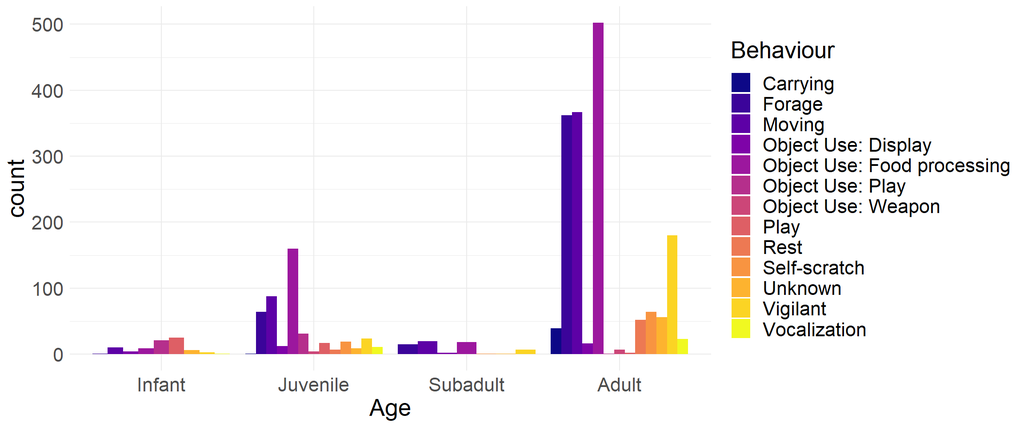

```r
ggplot(ObjectUse, aes(x = Age, fill = Behaviour)) +
    geom_bar(position = "dodge") +
  scale_fill_viridis_d(option = "C") +
  labs(fill = "Behaviour") + theme_minimal() +
  theme(text = element_text(size=20))
```

### Behaviour per Sex (%) barplot

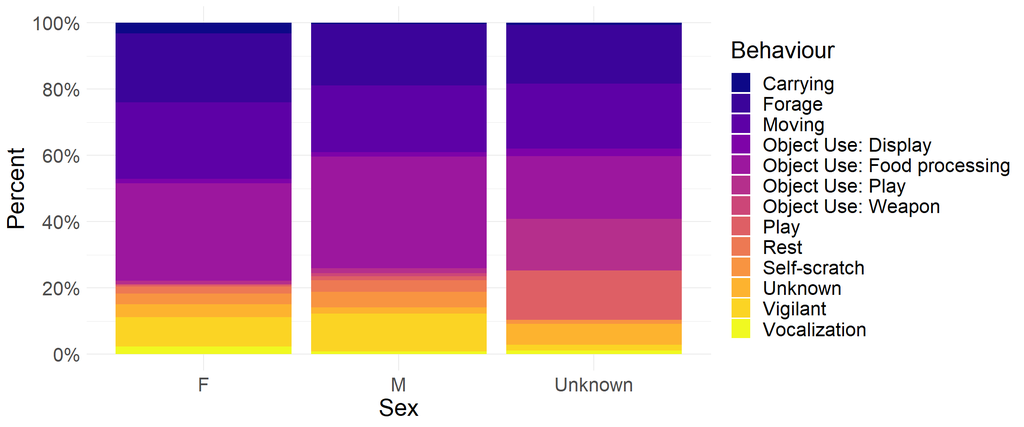

```r
ggplot(ObjectUse, aes(x = Sex, fill = Behaviour)) +
  geom_bar(position = "fill") +
  scale_y_continuous(breaks = seq(0, 1, .2), label = scales::percent) +
  scale_fill_viridis_d(option = "C") +
  labs(y = "Percent") + theme_minimal() +
  theme(text = element_text(size=20))
```

### Behaviour per Sex (count) barplot

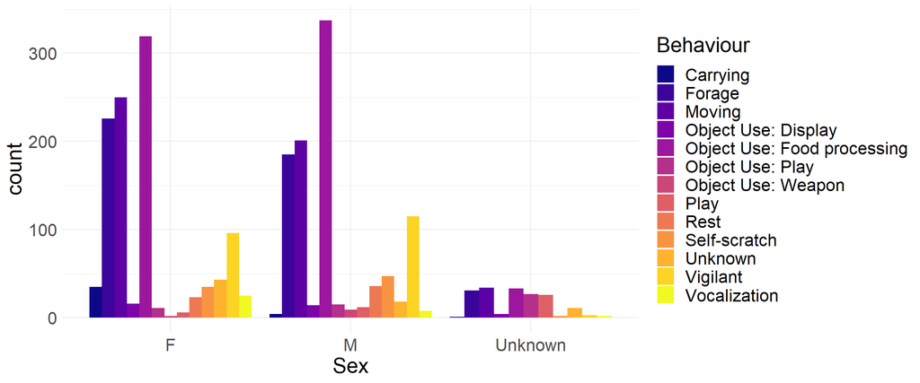

```r
ggplot(ObjectUse, aes(x = Sex, fill = Behaviour)) +
  geom_bar(position = "dodge") +
  scale_fill_viridis_d(option = "C") +
  theme_minimal() + theme(text = element_text(size=20))
```

### Behaviour per Group (%) barplot

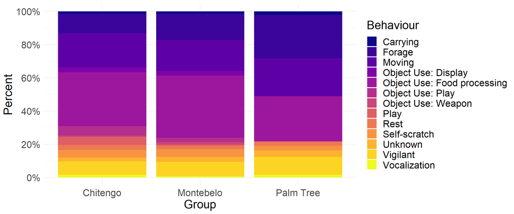

```r
ggplot(ObjectUse, aes(x = group_ID, fill = Behaviour)) +
  geom_bar(position = "fill") +
  scale_y_continuous(breaks = seq(0, 1, .2), label = scales::percent) +
  scale_fill_viridis_d(option = "C") +
  labs(fill = "Behaviour", x = "Group", y = "Percent") +
  theme_minimal() + theme(text = element_text(size=20))
```

### Behaviour per Group (count) barplot

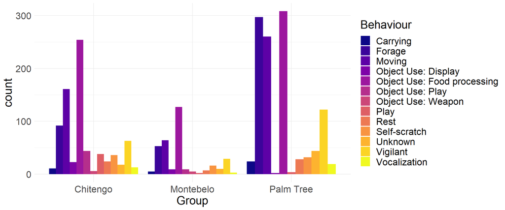

```r
ggplot(ObjectUse, aes(x = group_ID, fill = Behaviour)) +
    geom_bar(position = "dodge") +
  scale_fill_viridis_d(option = "C") +
  labs(fill = "Behaviour", x = "Group") + theme_minimal() +
  theme(text = element_text(size=20))
```

### Object Function per Group (%) barplot

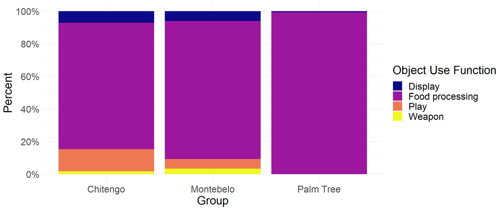

```r
ggplot(functionset, aes(x = group_ID, fill = ObjFunction)) +
  geom_bar(position = "fill") +
  scale_y_continuous(breaks = seq(0, 1, .2), label = scales::percent) +
  scale_fill_viridis_d(option = "C") +
  labs(fill = "Object Use Function", x = "Group", y = "Percent") +
  theme_minimal() + theme(text = element_text(size=20))
```

### Object Function per Group (count) barplot

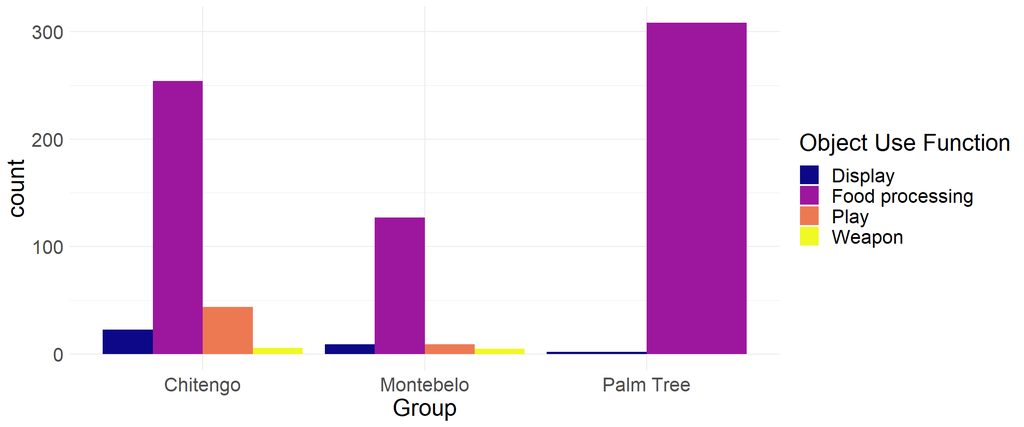

```r
ggplot(functionset, aes(x = group_ID, fill = ObjFunction)) +
  geom_bar(position = "dodge") +
  scale_fill_viridis_d(option = "C") +
  labs(fill = "Object Use Function",
       x = "Group") +
  theme_minimal() + theme(text = element_text(size=20))
```

### Hand Laterality per Age class (%) barplot

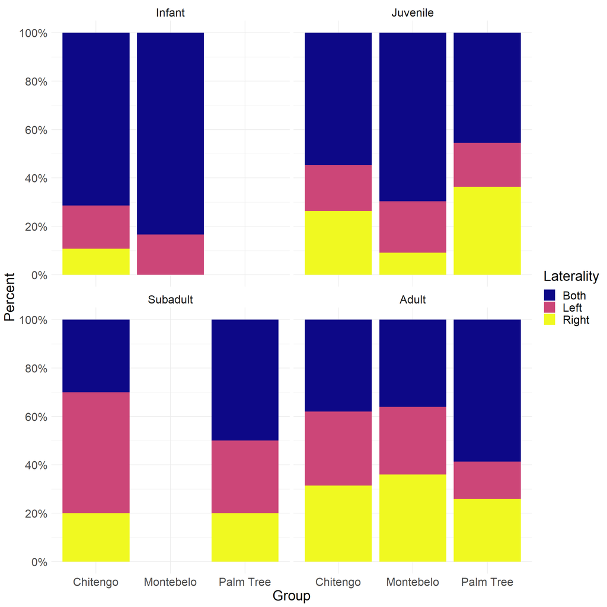

```r
ggplot(functionset, aes(x = group_ID, fill = Obj_Lat)) +
  geom_bar(position = "fill") +
  scale_y_continuous(breaks = seq(0, 1, .2), label = scales::percent) +
  scale_fill_viridis_d(option = "C") +
  labs(fill = "Laterality", x = "Group", y = "Percent") +
  theme_minimal() + theme(text = element_text(size=20)) +
  facet_wrap(~ Age)
```

### Hand Laterality per Age class (count) barplot

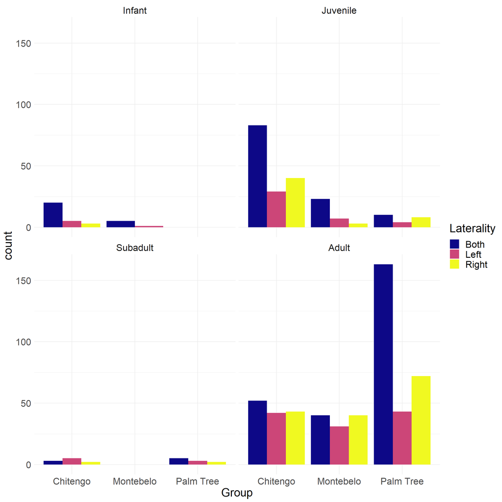

```r
ggplot(functionset, aes(x = group_ID, fill = Obj_Lat)) +
  geom_bar(position = "dodge") +
  scale_fill_viridis_d(option = "C") +
  labs(fill = "Laterality", x = "Group") + theme_minimal() +
  theme(text = element_text(size=20)) + facet_wrap(~ Age)
```

### Type of play (count) per group barplot

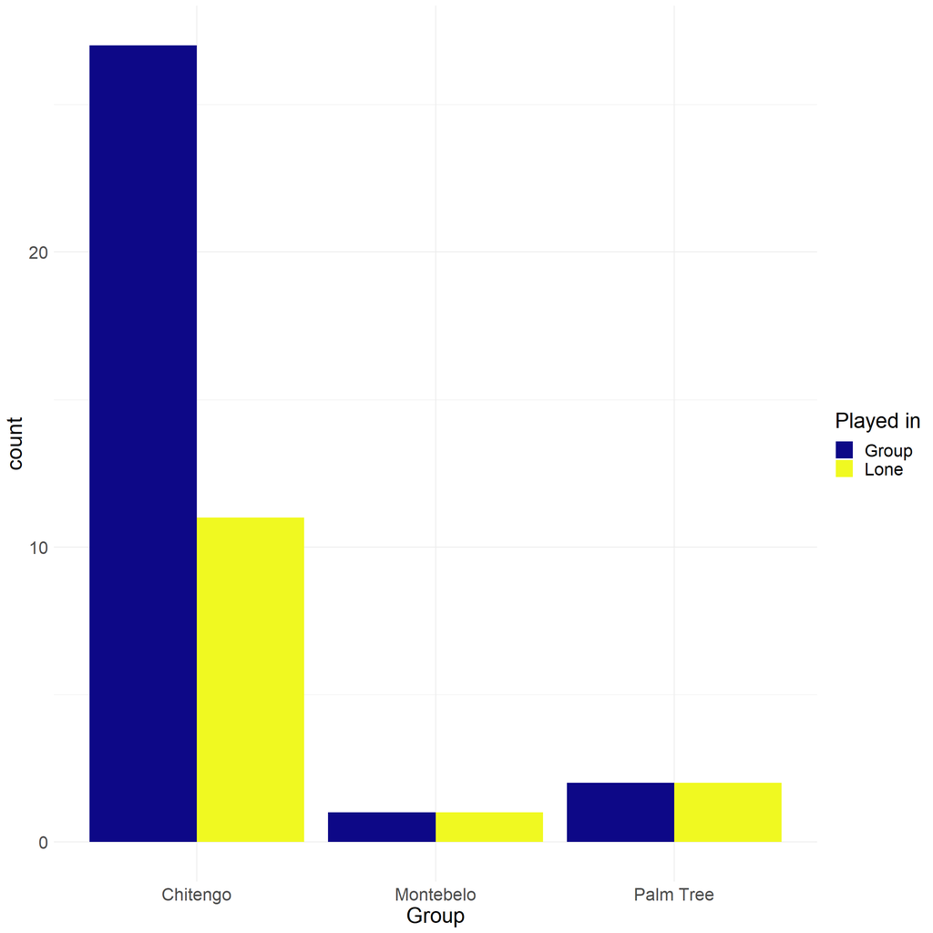

```r
ggplot(playset, aes(x = group_ID, fill = Play_Type)) +
  geom_bar(position = "dodge") +
  scale_fill_viridis_d(option = "C") +
  labs(fill = "Played in", x = "Group") + theme_minimal() +
  theme(text = element_text(size=20))
```

### Type of play (count) per age barplot

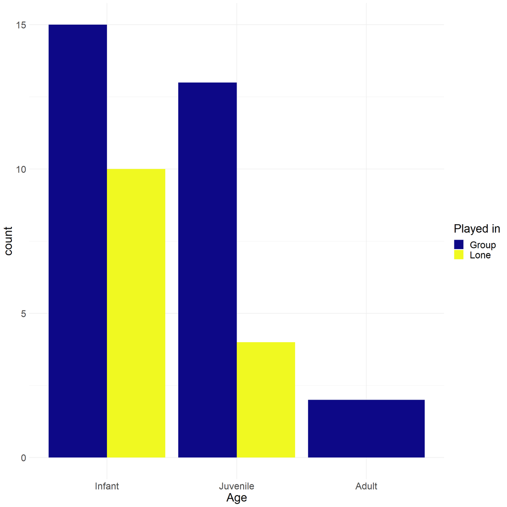

```r
ggplot(playset, aes(x = Age, fill = Play_Type)) +
  geom_bar(position = "dodge") +
  scale_fill_viridis_d(option = "C") +
  labs(fill = "Played in", x = "Age") + theme_minimal() +
  theme(text = element_text(size=20))
```

### Type of play (count) per sex barplot

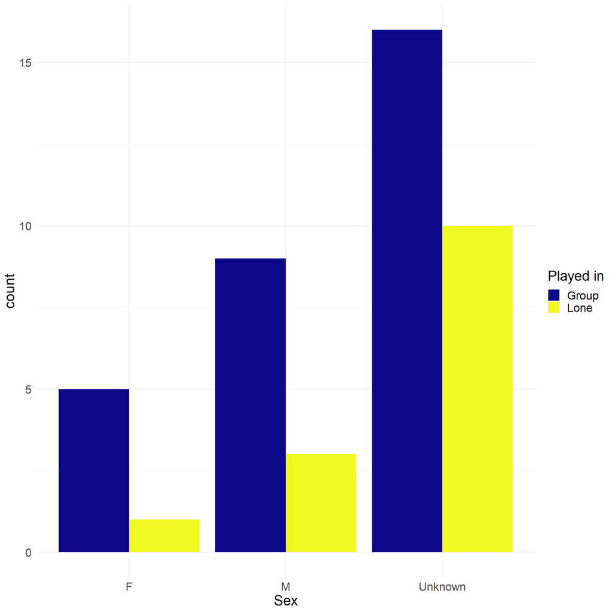

```r
ggplot(playset, aes(x = Sex, fill = Play_Type)) +
  geom_bar(position = "dodge") +
  scale_fill_viridis_d(option = "C") +
  labs(fill = "Played in", x = "Sex") + theme_minimal() +
  theme(text = element_text(size=20))
```

### Type of play (count) per habitat barplot

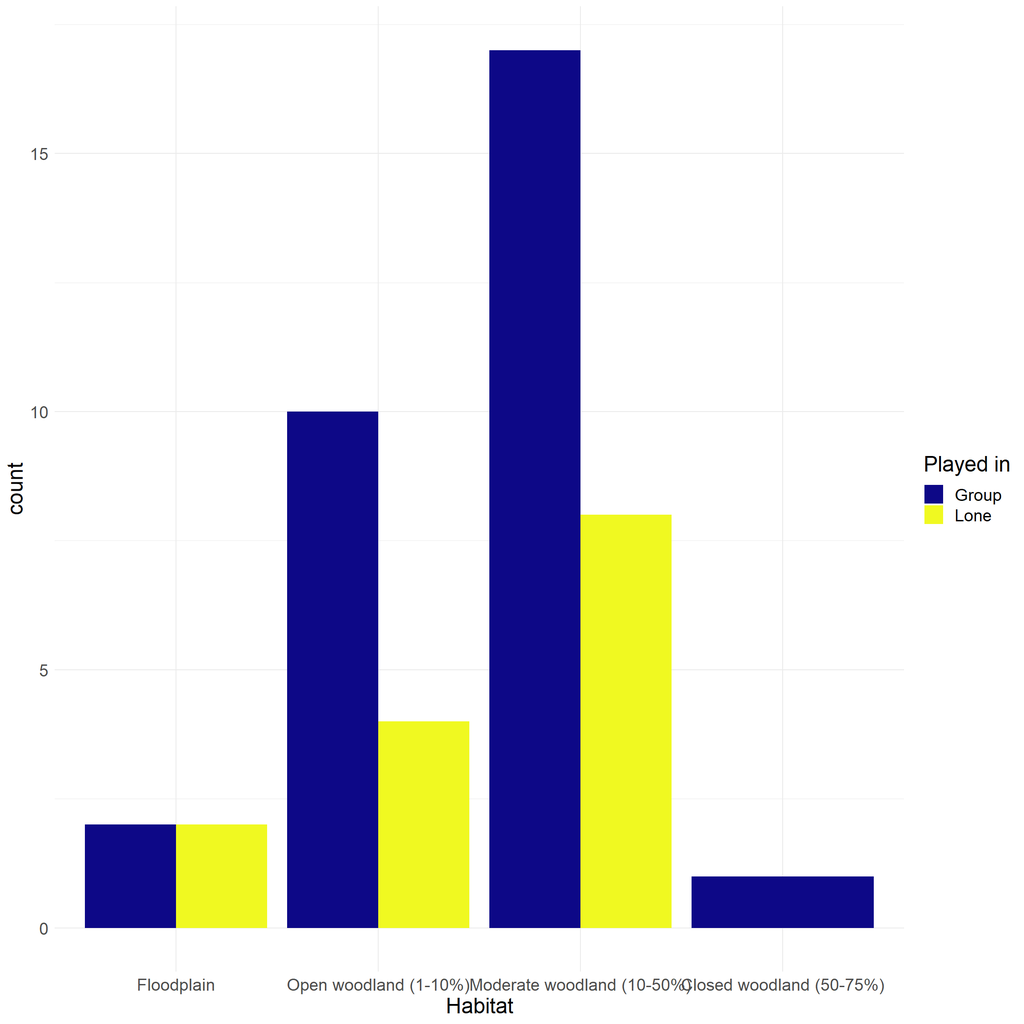

```r
ggplot(playset, aes(x = Habitat, fill = Play_Type)) +
  geom_bar(position = "dodge") +
  scale_fill_viridis_d(option = "C") +
  labs(fill = "Played in", x = "Habitat") + theme_minimal() +
  theme(text = element_text(size=18))
```

### Object or non-object play (count) per group barplot

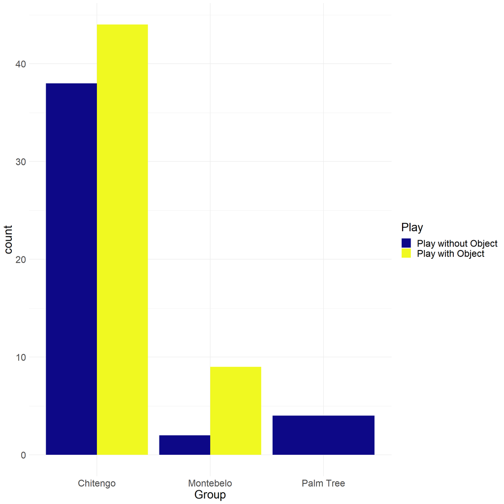

```r
ggplot(objPlayset, aes(x = group_ID, fill = Play_Obj)) +
  geom_bar(position = "dodge") +
  scale_fill_viridis_d(option = "C") +
  labs(fill = "Play", x = "Group") + theme_minimal() +
  theme(text = element_text(size=20))
```

### Object or non-object play (count) per age barplot

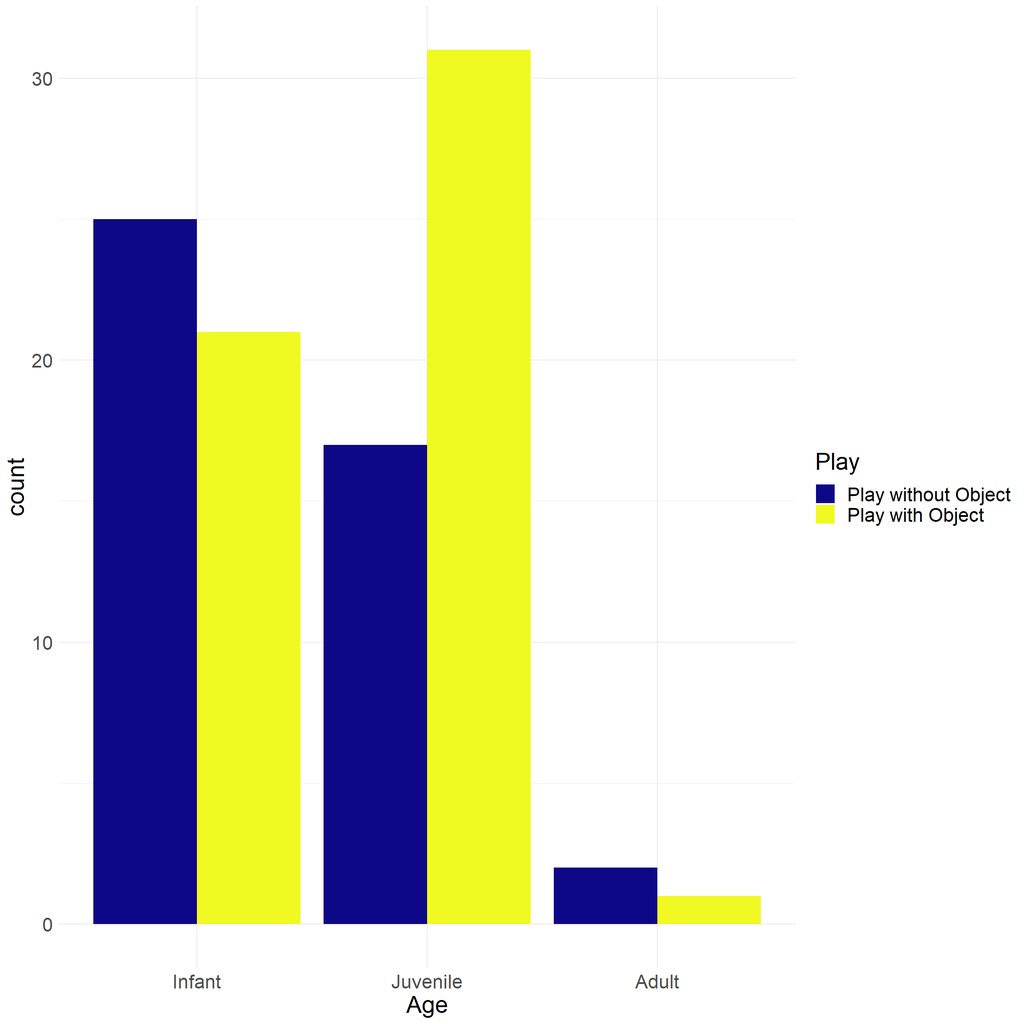

```r
ggplot(objPlayset, aes(x = Age, fill = Play_Obj)) +
  geom_bar(position = "dodge") +
  scale_fill_viridis_d(option = "C") +
  labs(fill = "Play", x = "Age") + theme_minimal() +
  theme(text = element_text(size=20))
```

### Intrinsic factors mosaic plot

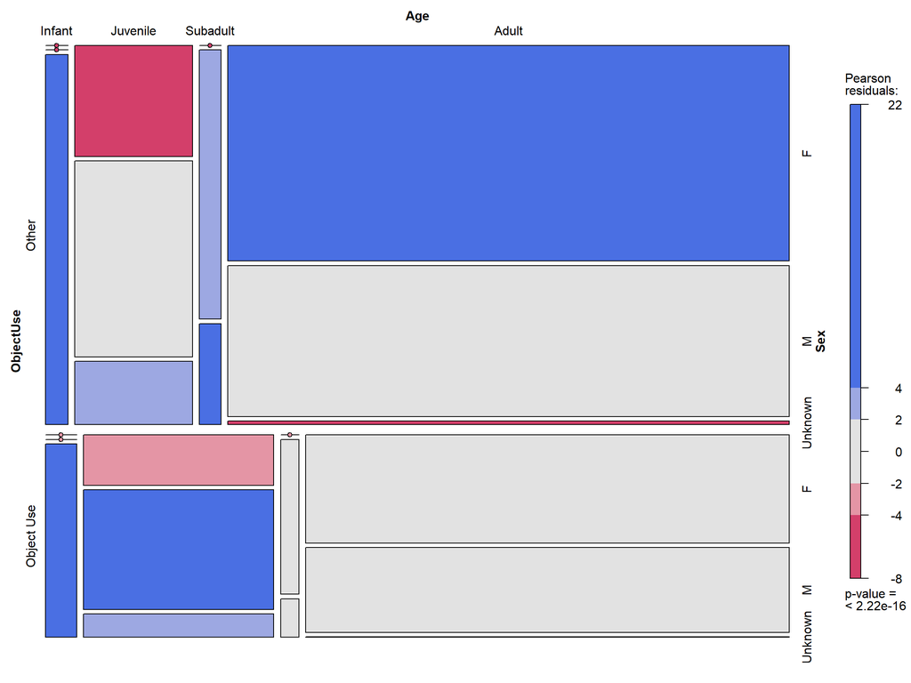

```r
library(vcd)
library(viridis)

# create a contingency table
marimekko <- table(ObjectUse[c("ObjectUse", "Age", "Sex")])
# mosaic plot from vcd package
mosaic(marimekko, shade = TRUE)
```

In a mosaic plot, the shading of the rectangles can be used to display additional information about the data, such as the standardized residuals. The standardized residuals are a measure of how far the observed values in each cell of the contingency table deviate from the expected values under a given statistical model. In the case of a mosaic plot, the standardized residuals can be represented by the color of the rectangles.

Pearson residuals are one way to calculate the standardized residuals. The Pearson residual for a cell is defined as the difference between the observed count and the expected count in that cell, divided by the square root of the expected count. It is a measure of the deviance of the observed count from the expected count.

A Mosaic Plot is also a good way to see if there are any biases in the data collection, or structures that might cause troubles in modelling. E.g. we can quickly see that no female sub-adults were sampled and therefore we cannot make any inferences about this demographic group.

## 4. Mixed-effects Logistic Regression Model

In this case, the glmmTMB package was used because it is a flexible and powerful tool for fitting generalized linear mixed-effects models. Compared to the more commonly used lme4 package, glmmTMB offers several advantages, including faster computation times and better handling of complex data structures. One particular advantage of glmmTMB is its ability to fit a wider range of probability distributions, including zero-inflated and overdispersed count data. Additionally, glmmTMB provides more options for model fitting, such as allowing for non-Gaussian random effects and specifying correlation structures for the random effects. These features make glmmTMB a versatile tool for fitting a wide variety of mixed-effects models with both continuous and categorical response variables, making it a good choice for the current analysis.

```r
library(glmmTMB)

model <- glmmTMB(ObjectUse ~ Habitat + Age + Sex + (1|group_ID), data = ObjectUse, family = binomial(link = "logit"))

model
```

```
## Formula:          ObjectUse ~ Habitat + Age + Sex + (1 | group_ID)
## Data: ObjectUse
##       AIC       BIC    logLik  df.resid
##  2872.735  2935.699 -1425.367      2251
## Random-effects (co)variances:
##
## Conditional model:
##  Groups   Name        Std.Dev.
##  group_ID (Intercept) 4.293e-05
##
## Number of obs: 2262 / Conditional model: group_ID, 3
##
## Fixed Effects:
##
## Conditional model:
##                       (Intercept)       HabitatSparse woodland (<1%)
##                          -0.31590                            0.03749
##      HabitatOpen woodland (1-10%)  HabitatModerate woodland (10-50%)
##                           0.65029                            0.17623
##   HabitatClosed woodland (50-75%)                        AgeJuvenile
##                           0.40547                           -0.19380
##                       AgeSubadult                           AgeAdult
##                          -0.50429                           -0.67014
##                              SexM                         SexUnknown
##                           0.01978                           -0.27901
```

In this example, `ObjectUse` is the binary outcome (response variable), `Habitat`, `Age`, and `Sex` are fixed effects (i.e., predictor variables of interest), and `group_ID` is a grouping variable for the random intercept. The syntax `(1|group_ID)` specifies that there should be a random intercept for each level of `group_ID`.

```r
knitr::kable(summary(model)$coef) # formatted table for word
```

|  | Estimate | Std. Error | z value | Pr(>\|z\|) |
| --- | --- | --- | --- | --- |
| (Intercept) | -0.3158980 | 0.3520495 | -0.8973114 | 0.3695528 |
| HabitatSparse woodland (<1%) | 0.0374919 | 0.1803871 | 0.2078416 | 0.8353526 |
| HabitatOpen woodland (1-10%) | 0.6502928 | 0.1265444 | 5.1388508 | 0.0000003 |
| HabitatModerate woodland (10-50%) | 0.1762312 | 0.1224378 | 1.4393526 | 0.1500506 |
| HabitatClosed woodland (50-75%) | 0.4054718 | 0.2199866 | 1.8431664 | 0.0653047 |
| AgeJuvenile | -0.1938006 | 0.3234961 | -0.5990816 | 0.5491185 |
| AgeSubadult | -0.5042884 | 0.4085500 | -1.2343369 | 0.2170774 |
| AgeAdult | -0.6701374 | 0.3396882 | -1.9728013 | 0.0485182 |
| SexM | 0.0197782 | 0.1015683 | 0.1947280 | 0.8456059 |
| SexUnknown | -0.2790132 | 0.2500736 | -1.1157242 | 0.2645402 |

[output not shown]

[output not shown]

## 5. Model validity

There are several diagnostic tools that you can use to check the assumptions of your mixed-effects logistic regression model:

5.1. **Summary of the GLMM**

```r
options(width = 300)

summary(model)
```

```
##  Family: binomial  ( logit )
## Formula:          ObjectUse ~ Habitat + Age + Sex + (1 | group_ID)
## Data: ObjectUse
##
##      AIC      BIC   logLik deviance df.resid
##   2872.7   2935.7  -1425.4   2850.7     2251
##
## Random effects:
##
## Conditional model:
##  Groups   Name        Variance  Std.Dev.
##  group_ID (Intercept) 1.843e-09 4.293e-05
## Number of obs: 2262, groups:  group_ID, 3
##
## Conditional model:
##                                   Estimate Std. Error z value Pr(>|z|)
## (Intercept)                       -0.31590    0.35205  -0.897   0.3696
## HabitatSparse woodland (<1%)       0.03749    0.18039   0.208   0.8354
## HabitatOpen woodland (1-10%)       0.65029    0.12654   5.139 2.76e-07 ***
## HabitatModerate woodland (10-50%)  0.17623    0.12244   1.439   0.1501
## HabitatClosed woodland (50-75%)    0.40547    0.21999   1.843   0.0653 .
## AgeJuvenile                       -0.19380    0.32350  -0.599   0.5491
## AgeSubadult                       -0.50429    0.40855  -1.234   0.2171
## AgeAdult                          -0.67014    0.33969  -1.973   0.0485 *
## SexM                               0.01978    0.10157   0.195   0.8456
## SexUnknown                        -0.27901    0.25007  -1.116   0.2645
## ---
## Signif. codes:  0 '***' 0.001 '**' 0.01 '*' 0.05 '.' 0.1 ' ' 1
```

5.2. **Residual plots: You can use the plot() function from the lme4 package to create residual plots. For example, to create a residual vs. fitted plot, you can use the following code:**

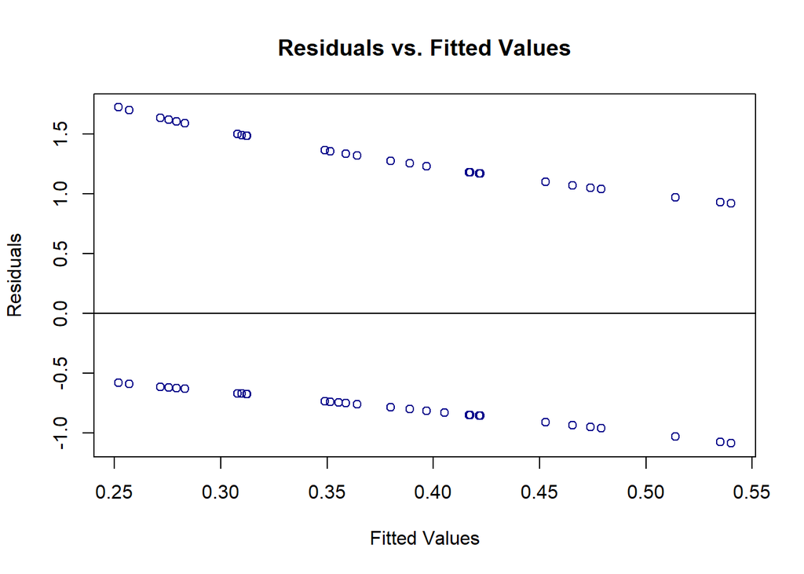

```r
# Plot residuals against predicted probabilities
residuals <- residuals(model, type = "pearson")
fitted.values <- fitted(model)

plot(fitted.values, residuals, col = "darkblue",
     ylab = "Residuals", xlab = "Fitted Values",
     main = "Residuals vs. Fitted Values", abline(h = 0))
```

This plot will show you if there is any pattern in the residuals. In logistic regression, it is common to see a parallel-lines pattern in the residuals vs fitted plot, with two smooth curves, rather than a random scatter of points. This is because the logistic regression model is non-linear and the relationship between the predictors and the response variable is typically non-linear.

To evaluate the residuals vs fitted plot in logistic regressions, you should look for:

- Spread of residuals: The spread of residuals should be roughly constant across the range of fitted values. If the spread is not constant, it may indicate heteroscedasticity (non-constant variance) in the residuals.
- Outliers: You should check for outliers, which are residuals that are far from the rest of the residuals. Outliers may indicate influential observations or errors in the data.
- Heteroskedasticity: You should check for heteroskedasticity, which is a situation where the residuals have different variances for different fitted values. This can be checked using a Scale-Location plot.
- Lack of fit: If the residuals show a clear pattern, such as a both curves being negative (or positive), or a lack of symmetry, it may indicate that the model does not fit the data well.

5.3. **Multicollinearity: You can use the vif() function from the car package to check for multicollinearity among the predictor variables. No multicollinearity: The predictor variables should not be highly correlated with each other.**

```r
# library(car)
# # Check for multicollinearity
# vif_table <- vif(model)
# knitr::kable(vif_table)
```

The variance inflation factor (VIF) is a measure of how much the variance of the estimated regression coefficient of one predictor variable is increased due to the presence of other predictor variables in the model. A VIF of 1 indicates that the predictor variable is not correlated with any of the other predictor variables and therefore has no multicollinearity issues. A VIF greater than 1 indicates that the predictor variable is correlated with one or more other predictor variables and the magnitude of the VIF gives an indication of the degree of multicollinearity.

*A general rule of thumb is that a VIF value greater than 5 or 10 indicates high multicollinearity and that one of the correlated predictor variables should be removed from the model*. However, this threshold can vary depending on the specific context and the number of predictors in the model.

5.4. **Model fit: Assess the model fit using a goodness-of-fit statistic such as the deviance or the AIC/BIC.**

```r
# deviance
# deviance(model)

# AIC/BIC
AIC(model)
```

```
## [1] 2872.735
```

```r
BIC(model)
```

```
## [1] 2935.699
```

A lower value of deviance or AIC/BIC indicates a better-fitting model.

Deviance, Akaike Information Criterion (AIC), and Bayesian Information Criterion (BIC) are all measures of model fit that can be used to compare different models. However, they differ in their underlying assumptions and the information they use to evaluate model fit.

- Deviance is a measure of the difference between the observed data and the predicted data under a given model. It is based on the likelihood function of the model and is closely related to the residual sum of squares in linear regression. It is a measure of how well the model fits the data, with lower values indicating a better fit.
- AIC is a measure of the relative quality of a statistical model, it balances the goodness of fit of the model with the complexity of the model. AIC is defined as twice the difference between the log-likelihood of the data under the estimated model and the maximum log-likelihood possible. A lower AIC value indicates a better model fit.
- BIC is also a measure of the relative quality of a statistical model, similar to AIC. BIC is defined as the log-likelihood of the estimated model, minus the number of parameters in the model times the natural logarithm of the sample size. Like AIC, a lower BIC value indicates a better model fit.

Both AIC and BIC take into account the number of parameters in the model and the sample size, which helps to penalize models with more parameters. This helps to avoid overfitting and to choose the simplest model that still explains the data well.

In short, deviance is a measure of how well a model fits the data, AIC and BIC are measures of how well a model fits the data relative to its complexity. Deviance is based on likelihood, AIC and BIC are based on likelihood and complexity, and AIC and BIC are used to compare different models and select the best one.

5.5. **Overdispersion: Compare the residual deviance to the residual degrees of freedom, if the deviance is much larger than the residual degrees of freedom, this is an indication of overdispersion.**

```r
# To check overdispersion, you can use the dispersion_glmer() function from the package "blmeco" which provides tools for fitting Bayesian linear mixed-effects models using the Stan software.

# load the package
# library(blmeco)
#
# # check overdispersion
# dispersion_glmer(model)
```

The dispersion_glmer() function returns the ratio of the deviance to the residual degrees of freedom (residual deviance divided by the residual degrees of freedom). In a well-specified model, this ratio should be close to 1. A ratio greater than 1 indicates some degree of overdispersion, which means that the variance of the residuals is greater than the variance predicted by the model.

It is important to test for overdispersion in a logistic GLMM because if overdispersion is present and not accounted for, it can lead to incorrect inferences and conclusions about the model’s parameters and significance. If overdispersion is detected, one can use a quasibinomial or negative binomial distribution instead of a standard binomial distribution to model the data.

Overdispersion is not always present, and sometimes the standard binomial GLMM can be a good fit. Additionally, even if overdispersion is present, it does not always mean that the results will be biased and it could depend on the specific scenario and data.

## Sub-model for Object Function analysis

Notice that the majority of object use (function) was described as “food processing”, a model with all classes was giving an error:

```r
table(functionset$ObjFunction)
```

```
##
##                         Display Food processing            Play          Weapon
##               0              34             689              53              11
```

Therefore we grouped the variables with few observations as “Object manipulation” vs “Food processing”

```r
table(functionset$ObjectFunction)
```

```
##
## Object manipulation     Food processing
##                  98                 689
```

This model worked properly, as you can see below:

```r
# Fit the model
model_objFunction <- glmer(ObjectFunction ~ Habitat + Age + Sex + Location + Obj_Lat + (1|group_ID), data = functionset, family = binomial(link = "logit"))

model_objFunction
```

```
## Generalized linear mixed model fit by maximum likelihood (Laplace Approximation) ['glmerMod']
##  Family: binomial  ( logit )
## Formula: ObjectFunction ~ Habitat + Age + Sex + Location + Obj_Lat + (1 |      group_ID)
##    Data: functionset
##       AIC       BIC    logLik  deviance  df.resid
##  417.6864  487.7098 -193.8432  387.6864       772
## Random effects:
##  Groups   Name        Std.Dev.
##  group_ID (Intercept) 0.9461
## Number of obs: 787, groups:  group_ID, 3
## Fixed Effects:
##                       (Intercept)       HabitatSparse woodland (<1%)       HabitatOpen woodland (1-10%)  HabitatModerate woodland (10-50%)    HabitatClosed woodland (50-75%)                        AgeJuvenile                        AgeSubadult                           AgeAdult
##                            2.1928                            -0.2474                            -2.1386                            -1.7111                            -1.4687                             1.3537                             0.8211                             2.1254
##                              SexM                         SexUnknown                     LocationRaised                       LocationTree                        Obj_LatLeft                       Obj_LatRight
##                            0.3948                            -1.0819                            -1.5871                            -1.7583                             1.5166                             0.7206
```

```r
summary(model_objFunction)
```

```
## Generalized linear mixed model fit by maximum likelihood (Laplace Approximation) ['glmerMod']
##  Family: binomial  ( logit )
## Formula: ObjectFunction ~ Habitat + Age + Sex + Location + Obj_Lat + (1 |      group_ID)
##    Data: functionset
##
##      AIC      BIC   logLik deviance df.resid
##    417.7    487.7   -193.8    387.7      772
##
## Scaled residuals:
##      Min       1Q   Median       3Q      Max
## -15.6125   0.0526   0.1466   0.3273   2.3470
##
## Random effects:
##  Groups   Name        Variance Std.Dev.
##  group_ID (Intercept) 0.895    0.9461
## Number of obs: 787, groups:  group_ID, 3
##
## Fixed effects:
##                                   Estimate Std. Error z value Pr(>|z|)
## (Intercept)                         2.1928     1.4628   1.499 0.133870
## HabitatSparse woodland (<1%)       -0.2474     1.5032  -0.165 0.869252
## HabitatOpen woodland (1-10%)       -2.1386     1.3489  -1.585 0.112859
## HabitatModerate woodland (10-50%)  -1.7111     1.3082  -1.308 0.190866
## HabitatClosed woodland (50-75%)    -1.4687     1.4374  -1.022 0.306896
## AgeJuvenile                         1.3537     0.8274   1.636 0.101845
## AgeSubadult                         0.8211     1.1399   0.720 0.471330
## AgeAdult                            2.1254     0.9135   2.327 0.019987 *
## SexM                                0.3948     0.3177   1.243 0.213970
## SexUnknown                         -1.0819     0.7318  -1.478 0.139287
## LocationRaised                     -1.5871     0.5711  -2.779 0.005455 **
## LocationTree                       -1.7583     0.4142  -4.245 2.19e-05 ***
## Obj_LatLeft                         1.5166     0.4089   3.709 0.000208 ***
## Obj_LatRight                        0.7206     0.3329   2.164 0.030438 *
## ---
## Signif. codes:  0 '***' 0.001 '**' 0.01 '*' 0.05 '.' 0.1 ' ' 1
```

```
##
## Correlation matrix not shown by default, as p = 14 > 12.
## Use print(x, correlation=TRUE)  or
##     vcov(x)        if you need it
```